# Simulation Examples

Stat133  
26 Feb 2015

### Probability and Statistics

We can think of probability theory as complimentary to statistical inference.

**Probability Theory** : Probability Distribution \( \rightarrow \) Observed Data

**Statistical Inference** : Observed Data \( \rightarrow \) Probability Distribution

### A Statistic - review from last lecture

A **statistic** is often just a function of a random sample, for example the sample mean, the 95th quantile, or the sample proportion.

Statistics are often used as estimators of quantities of interest about the distribution, called parameters. Statistics are random variables (since they depend on the sample); parameters are not.

In simple cases, we can study the sampling distribution of the statistic analytically. For example, we can prove that under mild conditions the distribution of the sample proportion is close to normal for large sample sizes.

In more complicated cases, we turn to simulation.

### Simulation - Recap

The main idea in a simulation study is to replace the mathematical expression for a probability distribution (or model) with a sample from that distribution.

We use the sample to estimate features of the distribution, such as the behavior of various statistics under repeated sampling from the distribution.

Statisticians routinely use simulations to evaluate complicated methods for which exact mathematical results are difficult or impossible to obtain.

The downside: whereas mathematical results are symbolic, in terms of arbitrary parameters and sample size, in a simulation we must specify particular values.

### Steps of a Simulation Study

1. Specify what makes up an individual experiment: sample size, distributions, parameters, statistic of interest.
2. Write an expression or function to carry out an individual experiment and return the statistic.
3. Determine what inputs, if any, to vary (e.g. different sample sizes or parameters).
4. For each combination of inputs, repeat the experiment B times, providing B samples of the statistic.
5. For each combination of inputs, summarize the empirical distribution of the statistic of interest.
6. State and/or plot the results. (Sometimes go back to 3.)

Note: the large B is the better the approximation.

### First Example - Coin Flip

**Probability** allows us to quantify statements about the chance of an event taking place.

Example : Flip a fair coin

- What’s the chance it lands heads?
- Flip it 4 times, what proportion of heads do you expect?
- Will you get exactly that proportion?
- What happens when you flip the coin 1000 times?

### Probability Distribution - Coin Flip

| Seqence of flips | # Heads | Seqence of flips | # Heads |
| --- | --- | --- | --- |
| HHHH | 4 | HTTH | 2 |
| HHHT | 3 | THTH | 2 |
| HHTH | 3 | TTHH | 2 |
| HTHH | 3 | HTTT | 1 |
| THHH | 3 | THTT | 1 |
| HHTT | 2 | TTHT | 1 |
| HTHT | 2 | TTTH | 1 |
| THHT | 2 | TTTT | 0 |

16 possible sequences, each equally likely. The probability distribution for the random variable X=#heads in 4 flips is: \[ P(X=0)=\frac{1}{16}, P(X=1)=\frac{1}{4},P(X=2)=\frac{3}{8} \] \[ P(X=3)=\frac{1}{4},P(X=4)=\frac{1}{16} \]

### Statistic - Coin Flip

We can think of the number of Heads in 4 flips as a **statistic** because it summarizes data

Notice that it is a random quantity – it takes on 5 possible values, each with some probability.

### Coin Flip

1,000 Flips When we flip the coin 1,000 times, we can get a many different possible proportions of Heads, i.e. 0, 0.001, 0.002, 0.003, …, 0.998, 0.999, 1.000

It’s highly unlikely that we would get 0 for the proportion – how unlikely?

What does the distribution of the proportion of heads in 1000 flips look like?

### 1,000 Flips

- We can figure this out analytically.
- But we can also get a good idea using a simulation.
- In our simulation we will assume that the chance of Heads is 0.5 and find out what the possible values for the proportion of heads in 1,000 flips looks like.
- If we were to carry out an experiment with a coin and get a particular proportion, say 0.37, then we could use this simulation study to help us understand the results of our experiment.

### Sampling from a discrete set

To carry out the simulation study we use the function:

sample(x, size, replace = FALSE, prob = NULL)

Think of an urn with tickets, each ticket marked with a value. Mix up the tickets and draw one at a time from the urn

- x = vector with one element for each ticket, values correspond to what is written on the ticket.
- size = number of draws to take from the urn
- replace = replace the ticket between draws or not.
- prob = set of weights for the elements in x (an element might represent more than one ticket)

### Coin Flip in R

```r
set.seed(1101)
coin = c("T", "H")

# Flip the coin once
sample(coin, 1, replace = TRUE)
```

```
[1] "T"
```

```r
# Flip the coin 4 times
n = 4
tosses = sample(coin, n, replace = TRUE)
tosses
```

```
[1] "H" "T" "H" "T"
```

### Coin Flip in R - fraction of Heads

How many Heads did we get?

```r
sum(tosses == "H")
```

```
[1] 2
```

What proportion of Heads did we get?

```r
sum(tosses == "H")/length(tosses)
```

```
[1] 0.5
```

### Coin Flip in R - function

It might be easier to track using 0 for tails and 1 for heads

```r
coin = 0:1
n = 4
tosses = sample(coin, n, replace = TRUE)
```

And we can put this into a function, coinToss(), that takes one argument, n=#coin tosses, and return the *fraction* of tosses that came up Heads (or 1 in this case).

```r
coinToss = function(n=4){
  return( sum(sample(0:1, n, replace=TRUE)/n) )
}
```

### Coin Flip Simulation

What about estimating the distribution of the proportion or number of heads in 4 tosses?

Note that is the distrubution on slide 2.

We could conduct an experiment where we run our 4-toss process many many times and see empirically what proportion of the times did we get 0, 1, 2, 3, or 4 heads.

We will present three ways to do this in R.

### Coin Flip Simulation with a for-loop

We use the function coinToss() that we just created.

```r
n.toss <- 4
n.iter <- 1000

# initialize samplesA
samplesA = numeric()

for (i in 1:n.iter){
  samplesA[i] = coinToss(n.toss)
}
length(samplesA)
```

```
[1] 1000
```

```r
table(samplesA)/n.iter
```

```
samplesA
    0  0.25   0.5  0.75     1
0.074 0.288 0.329 0.241 0.068
```

```r
c(1/16, 1/4, 3/8, 1/4, 1/16)
```

```
[1] 0.0625 0.2500 0.3750 0.2500 0.0625
```

### Coin Flip Simulation with replicate()

Notice that the index *i* in the for-loop was only used to enumerate the number of times we called the function and the call to coinToss() does not depend on *i*.  
We can use the replicate() function in R to replace for-loops in cases like these.

```r
samplesB = replicate(n.iter, coinToss(n.toss))

table(samplesB)/n.iter
```

```
samplesB
    0  0.25   0.5  0.75     1
0.064 0.240 0.400 0.225 0.071
```

### Coin Flip Simulation with sapply()

```r
samplesC = sapply(1:n.iter, function(iter){sum(sample(0:1, n.toss, replace=TRUE))/n.toss})

length(samplesC)
```

```
[1] 1000
```

```r
head(samplesC)
```

```
[1] 0.50 0.50 0.50 0.50 0.75 0.50
```

```r
table(samplesC)
```

```
samplesC
   0 0.25  0.5 0.75    1
  59  207  389  280   65
```

Of the three methods to simulate the coin toss which one do you prefer?

### Coin Flip

Notice that each time we get slightly different answers. That's because we are working with a “random” process and each time we get slightly different answers.

We can also use the computer to study the behavior of a chance process as the sample size increases.

For example, how does the proportion of heads behave as the number of flips increases?

### Coin Flip - fraction of Heads

Lets generate 2000 tosses (so just a sequence of T/H or 0/1)

```r
n = 2000
tosses = sample(coin, n, replace = TRUE)
```

We can calculate the *cumulative sum* of this sequence using the function cumsum(), and the cumulative proportion by dividing with the number of observations *so far*.

```r
cumProp = cumsum(tosses)/(1:n)
```

### Plot

Let's plot this

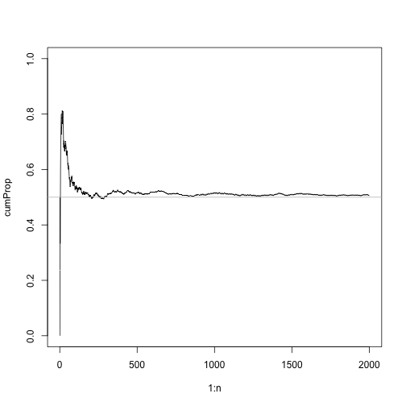

```r
plot(x = 1:n, y = cumProp, type = "l",  ylim = c(0, 1))
abline(h = 0.5, col = "grey")
```

### Plot

We can repeat this process a few times and overlay the plots. What do you notice?

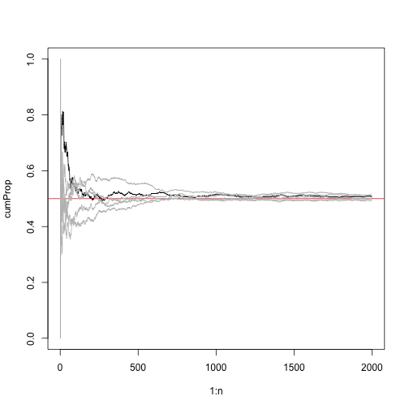

```r
plot(x = 1:n, y = cumProp, type = "l",  ylim = c(0, 1))
abline(h = 0.5, col = "red")
for(i in 1:5){
  tosses = sample(coin, n, replace = TRUE)
  cumProp = cumsum(tosses)/(1:n)
  lines(x = 1:n, y = cumProp, type = "l",  col="grey", ylim = c(0, 1))
}
```

### Functions to draw at random

In the coin toss example we only needed the function sample() to draw observations at random. Other commonly used functions follow.

### Uniform distribution

samples from the uniform distribution on the interval (0, 1).

```r
n = 10
runif(n, min = 0, max = 1)
```

```
 [1] 0.7420352 0.8582766 0.8380826 0.3833590 0.4961425 0.7931019 0.1532129
 [8] 0.4177698 0.5190493 0.4511704
```

The probability that the value drawn is in the interval a,b is b-a.

So the chance the value drawn is:

- between 0 and 1/3 has chance 1/3
- between 1/3 and ½ has chance 1/6
- between 9/10 and 1 has chance 1/10

The min and max allow you to change the interval from which to sample, e.g. min = 100, max = 150 will produce random values between 100 and 150

### Normal distribution

Standard Probability Distributions:

rnorm(n, mean = 0, sd = 1)

sample from the normal distribution with center = mean and spread = sd

### Binomial Distribution

rbinom(n, size, prob)

sample from the binomial distribution with number of trials = size and chance of success = prob

### Other distributions

rexp(), rpois(), rt(), rf() – each has arguments for parameter values relevant to the distribution.

See ?Distributions for more information

### Median of a Normal

Generate \( n \) random normal values from a \( N(0, s^2) \) and take the median of these \( n \) values

```r
n = 27
s = 3
median(rnorm(n = n, sd = s))
```

```
[1] 1.793677
```

### Median of a Normal

Repeat the experiment \( B \) times and examine the distribution of the \( B \) medians

```r
B = 1000
sampleMs = replicate(1000, median(rnorm(n = n, sd = s)))
mean(sampleMs)
```

```
[1] 0.04097606
```

```r
sd(sampleMs)
```

```
[1] 0.7187624
```

### Median of a Normal

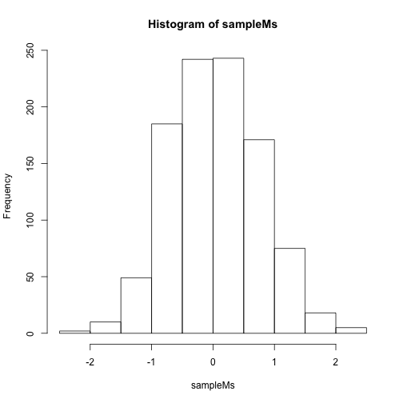

```r
hist(sampleMs)
```

### Repeat Simulation

Repeat the simulation for different values of \( n \) and \( s \) and compare/Examine the behavior for these different values

```r
ns = seq(20, 200, by = 10)
ss = seq(1, 10, by = 0.5)
samples = matrix(nrow = length(ns), ncol = length(ss))
for (i in 1:length(ns)) {
  for (j in 1:length(ss)) {
   samples[i , j] =  mean(replicate(1000, median(rnorm(n = ns[i], sd = ss[j]))))
  }
}
```

### Plot output

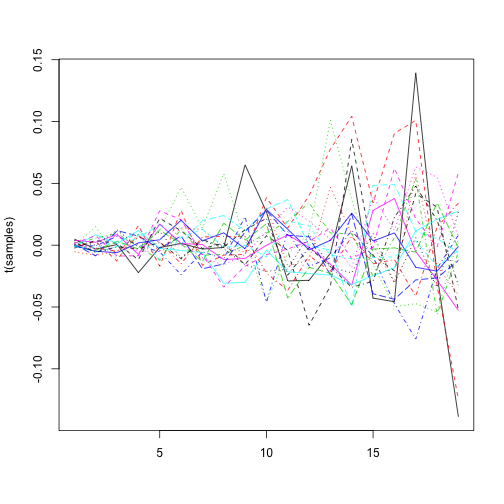

```r
matplot(t(samples), type="l")
```

### Biham-Middleton-Levine traffic model

A Simulation Study, question(s)

- Traffic flow in a large city grid
- Is there a largest traffic density that permits free flow?
- Is there a density above which gridlock is inevitable?

In 1992 Biham, Middleton and Levine introduced a simplified model for the study of these questions, called the BML model.

### BML Model

- Each intersection of a square grid of streets contains either a red car, a blue car, or an empty space.
- At each odd-numbered time step, all blue cars simultaneously attempt to move one unit North;
- A car succeeds if there is already an empty space for it to move into.
- At each even-numbered time step, the red cars attempt to move East in the same way.

### BML Model

- A blue car that falls off the North edge of the grid reappears in the same position at the South edge;
- Similarly red cars falling off the East edge reappear on the West edge.
- Initially, cars are distributed at random: each intersection is independently assigned a car with probability p, or an empty space with probability 1 - p.
- Each is car is independently equally likely to be red or blue.

### BML Model

Is there a density above whichgridlock is inevitable?

### Phase Transitions

BML is perhaps the simplest system exhibiting phase transitions and self organization General belief: the system exhibits a sharp phase transition from free flowing to fully jammed, depending on p – the initial density of cars.

### BML Model

- When p = 80%, traffic becomes jammed, and no car can move at all.
- For low densities (e.g. 10%), after a while traffic is completely free flowing, and no car ever has to wait at all.

The model appears to also exhibit large-scale organization:

- When p is 34% there is a single jam spanning the entire grid,
- At around 30% picture the cars arrange themselves into wide diagonal bands that avoid each other.
- At 32%, all cars move some of the time and wait some of the time, and this is achieved by semi-regular geometric patterns of jams feeding into each other.

BML Model(Wikipedia Page http://en.wikipedia.org/wiki/Biham-Middleton-Levine_traffic_model

### BML Model - Homework

- Representation of data
- functions
- What information do we want to store and look at

### Cross-Validation

Cross validation is a technique for assessing how well the results of some statistical analysis will generalize to an independent data set.

Using the same data to create the model as well as assess the model can lead to an overly optimistic view of how well the model will be able to make predictions in an independent data set.

The idea of cross validation is to leave some data aside as a test set (to assess the predictions) while the rest of the data is a training set used to make decisions about how to make predictions.

### Cross-Validation Example

Assume that both X and Y can only take the values 0 and 1. There are 4 possible values for (X, Y):

- X=0, Y=0
- X=0, Y=1
- X=1, Y=0
- X=1, Y=1

We wish to predict Y based on X, so we adopt the rule that :

- if X=0, predict Y=0, and
- if X=1, predict Y=1 (or predict 0, it doesn’t matter).

This will correctly predict Y ¾ of the time. Now suppose that both X and Y are the results of coin tosses, 50% chance of 0 or 1. Based on this, we know that future predictions will only be right half the time using this model.

### Cross-Validation

The idea of cross validation would be to

### Cross-Validation

If the first point is left out, our prediction rule remains the same and it will correctly predict the Y value for the value left out (the training set).

If the second is left out, the same thing will happen, correct prediction.

If the third or fourth points are left out, the prediction based on the other value will always be wrong.

In other words, if (1,0) is left out, the point (1,1) will tell us to predict Y=1 when X=1, and this prediction will be wrong for the point left out. Based on the test sets, correct predictions should only be expected half the time.

### Cross-Validation Code

Lets creat a toy example. We make a dataset with 30 observations on height, weight and GPA. Notice the structure in height and weight. Also note that GPA is independent of height and weight.

```r
ht = rep(c(65, 67, 69, 70, 71), each = 6)
wt = rep(c(120, 125, 130, 140, 150, 160), times = 5)
gpa = round(runif(30, min = 3.3, max = 4), 2)
aClass = data.frame(ht = ht, wt = wt, gpa = gpa)
```

### Cross Validation

Now let's try to predict GPA based on height and weight. We create a simple prediction system where we check if there is an individual in the training set with the given height and weight and match the GPA, if not we simply set the prediction to 4.

```r
myGrtPred = function(newH, newW, train = aClass){
  htMatch = which(newH == train$ht)
  wtMatch = which(newW == train$wt)
  bothMatch = which(htMatch %in% wtMatch)
  # if we found a match, pick the first match
  if (length(bothMatch) > 0) pred = train$gpa[htMatch[bothMatch[1]]]
  else pred = 4.0
  return(pred)
}
```

### Cross Validation

Use the model to predict the grade of someone with the height and weight of the first observation.

```r
myGrtPred(newH = aClass$ht[1], newW = aClass$wt[1])
```

```
[1] 3.86
```

```r
aClass$gpa[1]
```

```
[1] 3.86
```

### Prediction by row

```r
Preds = rep(0, nrow(aClass))
for (i in 1:nrow(aClass)){
  Preds[i] =
    myGrtPred(newH = aClass$ht[i], newW = aClass$wt[i])
}
#Preds = mapply(myGrtPred, newH = aClass$ht, newW = aClass$wt)

Preds
```

```
 [1] 3.86 3.83 3.56 3.55 3.46 3.39 3.91 3.34 3.58 3.46 3.63 3.84 3.74 4.00
[15] 3.41 3.41 3.79 3.76 3.31 3.45 3.96 3.68 3.82 3.70 3.97 3.48 3.69 3.50
[29] 3.88 3.50
```

```r
aClass$gpa
```

```
 [1] 3.86 3.83 3.56 3.55 3.46 3.39 3.91 3.34 3.58 3.46 3.63 3.84 3.74 4.00
[15] 3.41 3.41 3.79 3.76 3.31 3.45 3.96 3.68 3.82 3.70 3.97 3.48 3.69 3.50
[29] 3.88 3.50
```

```r
all(aClass$gpa == Preds)
```

```
[1] TRUE
```

### Cross Validation

```r
dim(aClass)
```

```
[1] 30  3
```

```r
mixUpRows = sample(nrow(aClass))

test = aClass[mixUpRows[1:15], ]
train = aClass[-mixUpRows[1:15], ]

#TestPreds = mapply(myGrtPred, newH = test$ht, newW = test$wt, train = train)

TestPreds = rep(0, nrow(test))
for (i in 1:nrow(test)){
  TestPreds[i] = myGrtPred(newH = test$ht[i],
                           newW = test$wt[i],
                           train = train)
}

sum(test$gpa == TestPreds)
```

```
[1] 1
```

### Number of correct predictions

```r
test = aClass[mixUpRows[16:30], ]
train = aClass[-mixUpRows[16:30], ]
correctPreds = rep(FALSE, nrow(test))
for (i in 1:nrow(test)){
  correctPreds[i] = test$gpa[i] == myGrtPred(newH = test$ht[i],  newW = test$wt[i], train = train)
}
sum(correctPreds)
```

```
[1] 0
```

### Bootstrap

A simple bootstrap function:

```r
bootStrapS = function(mySample, B = 1000){
    replicate(B, mean(sample(mySample, length(mySample), TRUE)))
}
```

### Bootstrap

Another version, what are we doing here?

```r
bootStrap = function(mySample, popSize = NULL, B = 1000, repl = FALSE){
  if (repl) {
    return(replicate(B, mean(sample(mySample, length(mySample), TRUE))))
  } else {
    vals = sort(unique(mySample))
    counts = table(mySample)
    bootPop = rep(vals, round(counts * popSize / length(mySample))) # create a new sample population
    return(list(bootPop, bootSamps = replicate(B, mean(sample(bootPop, length(mySample), FALSE)))))
  }
}
```

### Bootstrap

```r
mySample = rnorm(500)
bootSampAvgs = bootStrap(mySample, popSize = 1200)
length(bootSampAvgs[[2]])
```

```
[1] 1000
```

```r
head(bootSampAvgs[[2]])
```

```
[1]  0.02566414 -0.07087096  0.01657244 -0.08823856  0.04598010 -0.05248304
```

```r
mean(bootSampAvgs[[2]])
```

```
[1] -0.01273069
```

### Bootstrap

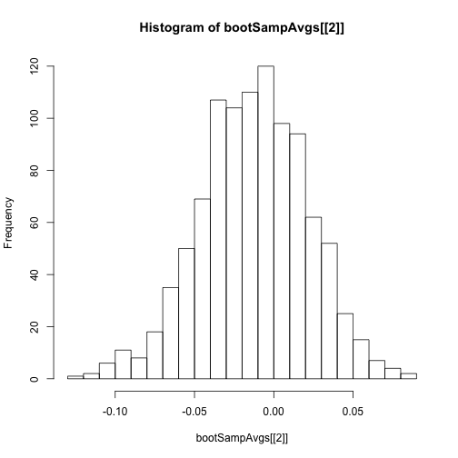

```r
hist(bootSampAvgs[[2]], breaks = 30)
```

### Bootstrap - Videogame Data

In Fall 1994, 314 students were enrolled in Stat 2, Section 1. Ninety-five were selected at random to participate in a survey. Amongst other questions, they were asked how many hours of video games they played in the last week. Ninety-one answered, and the average number of hours was 1.24 hours. How accurately does this estimate the population average?

### Bootstrap - Videogame Data

```r
videoSample =rep(c(0,.1,.5,1,1.5,2,3,4,5,14,30), times = c(57,1,5,5,1,14,3,1,1,2,1))
videoSample
```

```
 [1]  0.0  0.0  0.0  0.0  0.0  0.0  0.0  0.0  0.0  0.0  0.0  0.0  0.0  0.0
[15]  0.0  0.0  0.0  0.0  0.0  0.0  0.0  0.0  0.0  0.0  0.0  0.0  0.0  0.0
[29]  0.0  0.0  0.0  0.0  0.0  0.0  0.0  0.0  0.0  0.0  0.0  0.0  0.0  0.0
[43]  0.0  0.0  0.0  0.0  0.0  0.0  0.0  0.0  0.0  0.0  0.0  0.0  0.0  0.0
[57]  0.0  0.1  0.5  0.5  0.5  0.5  0.5  1.0  1.0  1.0  1.0  1.0  1.5  2.0
[71]  2.0  2.0  2.0  2.0  2.0  2.0  2.0  2.0  2.0  2.0  2.0  2.0  2.0  3.0
[85]  3.0  3.0  4.0  5.0 14.0 14.0 30.0
```

### Bootstrap - Videogame Data

```r
length(videoSample)
```

```
[1] 91
```

```r
mean(videoSample)
```

```
[1] 1.242857
```

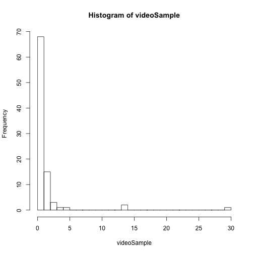

```r
hist(videoSample, breaks = 30)
```

### Bootstrap - Videogame Data

Notice that the empirical distribution has a very long tail and few observations in the tail.

The second version of the bootstrap function, where we scale up the population size, is useful in cases like these.

### Bootstrap - Videogame Data

```r
bootResults = bootStrap(videoSample, popSize = 314)
head(bootResults[[1]])
```

```
[1] 0 0 0 0 0 0
```

### Bootstrap - Videogame Data

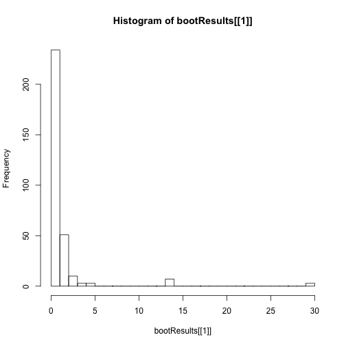

```r
hist(bootResults[[1]], breaks = 30)
```

### Bootstrap - Videogame Data

```r
length(bootResults[[2]])
```

```
[1] 1000
```

```r
head(bootResults[[2]])
```

```
[1] 0.9230769 1.7967033 1.9791209 1.2989011 1.3406593 1.2813187
```

```r
mean(bootResults[[2]])
```

```
[1] 1.189114
```

### Bootstrap - Videogame Data

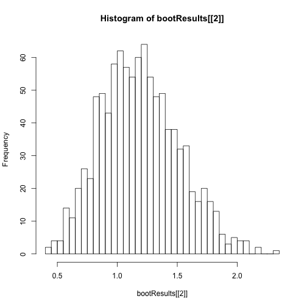

```r
hist(bootResults[[2]], breaks = 30)
```

### Web Caching

- When you use a search engine to look for a Web page, the search engine looks through its cache.
- The cache is created by regularly crawling the web and taking copies of every page that has changed since the last time it visited the site.
- It’s time consuming and costly to crawl the web.
- How often do you need to crawl the web in order to keep its stock fresh for the search engine?

### Web Caching

- Data: a collection of web sites were visited regularly over a period of time to see whether or not they had changed.
- Question: Given a new website, how often would you recommend as the length of time between visiting the site?

```r
load("Cache500.rda")
```

### Web Caching

```r
class(Cache500)
```

```
[1] "list"
```

```r
length(Cache500)
```

```
[1] 500
```

```r
names(Cache500)
```

```r
class(Cache500[[1]])
```

```
[1] "integer"
```

```r
length(Cache500[[1]])
```

```
[1] 206
```

### Web Caching

More generally, we are interested in

- the number of changes over the observed time period
- the “typical”“ length of time between changes
- the times at which a changes were observed

### Web Caching

Look e.g. at website 8:

```r
Cache500[[8]]
```

```
 [1]   3  23  30  32  39  42  45  62  78  82 147 151 155 175
```

```r
length(Cache500[[8]])
```

```
[1] 14
```

```r
diff(Cache500[[8]])
```

```
 [1] 20  7  2  7  3  3 17 16  4 65  4  4 20
```

### Web Caching

- How would you create a vector which stores the number of times each of the websites has changed?
- Using that variable how do you get a subset of vectors that only had few visits, or many visits?
- Did all the websites change?

### Web Caching - Time between changes

The time between changes might be

- Uniform
- Behave like a waiting time, i.e. Exponential
- Something else?

### Web Caching

You will be asked to answer some of these questions in the next homework, and write a couple of functions to assess what distribution the time between changes follows.

### Comparing Two Distributions

In many situations we want to either

- compare the distribution of some data to a particular probability distribution
- or compare the distributions of two samples

What is the best way to visually compare two distributions?

Can we do a formal statistical test to ask whether a dataset could come from a particular distribution?

### Comparing Two Distributions - Histograms

To compare the distribution on two datasets we can overlay the two histograms,

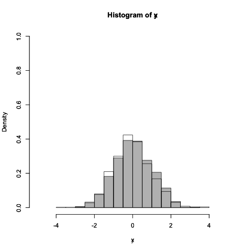

```r
x <- rnorm(1000)
y <- rt(n=1000, df=20)
hist(x, prob=TRUE, xlim=c(-5, 5), ylim=c(0,1), breaks=20, col="grey")
par(new=TRUE)
hist(y, prob=TRUE, xlim=c(-5, 5), ylim=c(0,1), breaks=20)
```

### Comparing Two Distributions - Histograms

Try different distributions

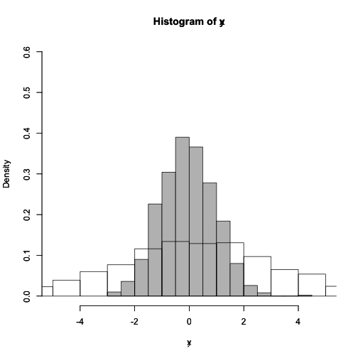

```r
x <- rnorm(1000, mean=0, sd=1)
y <- rnorm(1000, mean=0, sd=3)
hist(x, prob=TRUE, xlim=c(-5, 5), ylim=c(0,0.6), breaks=20, col="grey")
par(new=TRUE)
hist(y, prob=TRUE, xlim=c(-5, 5), ylim=c(0,0.6), breaks=20)
```

### Comparing Two Distributions - Densities

Or we could plot the estimated densities.

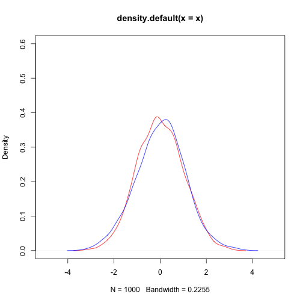

```r
x <- rnorm(1000)
y <- rt(n=1000, df=20)
plot(density(x), xlim=c(-5, 5), ylim=c(0,0.6), col="red")
lines(density(y), xlim=c(-5, 5), ylim=c(0,0.6), col="blue")
```

### Comparing Two Distributions - QQ-plots

It is often hard to judge from histograms or density plots whether differences are due to random variation or whether the distrubtions are actually different. A better visual tool is a quantile-quantile plot.

- Definition: the \( k^{th} \) q-quantile of a distribution is the value such that the probability that x is less than \( q_k \) is at most \( k/q \)
- Example: Quartiles are special cases of quantiles, the first quartile is the number such that 25% of the distrubtion falls below it, etc. For a dataset of size \( n \) we define the \( i \)-the quantile to be:\( P(X \leq x) \leq \frac{i}{n+1} \)

### QQ-plots - Examples

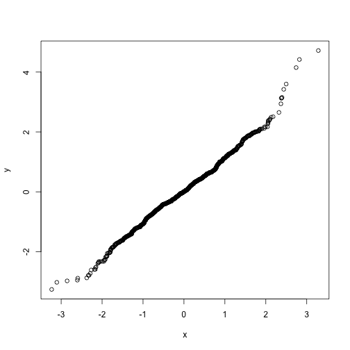

```r
x <- rnorm(1000)
y <- rt(n=1000, df=20)
qqplot(x, y)
```

### QQ-plots - Examples

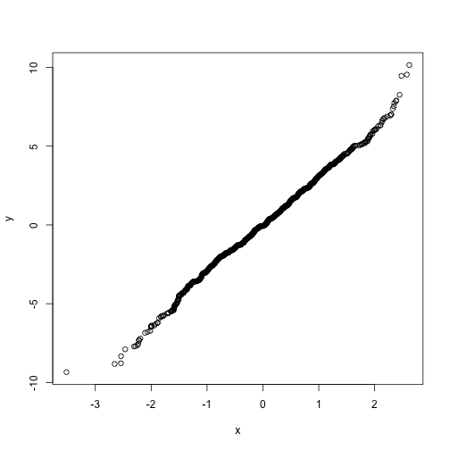

```r
x <- rnorm(1000, mean=0, sd=1)
y <- rnorm(1000, mean=0, sd=3)
qqplot(x, y)
```

### QQ-plots - Examples

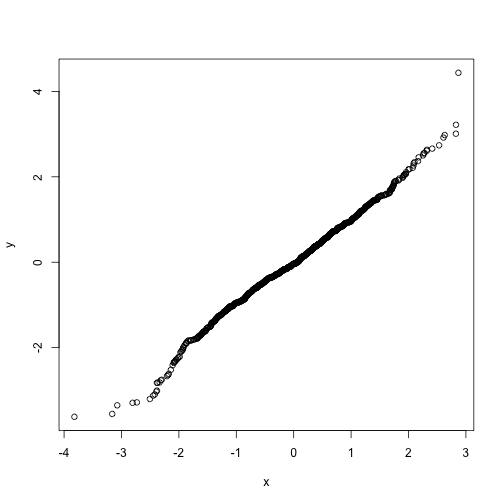

```r
x <- rnorm(1000)
y <- rt(n=1000, df=20)
qqplot(x, y)
```

### Kolmogorov-Smirnoff Test

- A nonparameteric test of the equality of two continuous probability distributions.
- Can be used to compare a sample to a reference distribution
- or to comapre two samples

### Kolmogorov-Smirnoff Test

The empirical distribution function \( F_n \) for n iid observations \( X_1, \dots, X_n \) is \[ F_n(x) = \frac{1}{n} \sum_{i=1}^n I_{X_i \leq x} \]

The KS test statistic is: \[ D_n = sup_x | F_n(x) - F(x) | \]

### Switch Gears

- You will use the KS test on your next homework.
- Now we switch gears again and look at a final simulation example

### Dependence

Most interesting examples in probability have a little dependence added in: “If it rained yesterday, what is the probability it rains today?”

Use this to generate weather patterns and probabilities for some time in the future. Almost always occurs with time series; can occur with other dependence (spatial – if it's sunny in Dallas today, will it also be sunny in Fort Worth?)

### Markov Dependence

Suppose we have a sequence of observations that are dependent. In a time series, what happens next depends on what happened before:

\[ p(X_1, X_2, ..., X_n) = p(X_1)p(X_2|X_1)...p(X_n|X_{n-1},...,X_1) \]

(Note: you could, of course, condition on the future to predict the past, if you had a time machine.)

Markov dependence: each outcome only depends on the one that came before.

\[ p(X_1, X_2, ..., X_n) = p(X_1)\prod_{i=2}^np(X_i|X_{i-1}) \]

### Generating a Markov Chain

1. Set up the conditional distribution.
2. Draw the initial state of the chain.
3. For every additional draw, use the previous draw to inform the new one.

### Simple weather model

- if it was sunny yesterday, today's chance of sun is 80%.
- if it wasn't sunny yesterday, today's chance of sun is 20%.

### Simulate for one year (at the equator?)

```r
sunny.year <- rep(NA, 365)
sunny.year[1] <- 1
for (day in 2:365) sunny.year[day] <- rbinom(1,1,0.2 + 0.6*sunny.year[day-1])
```

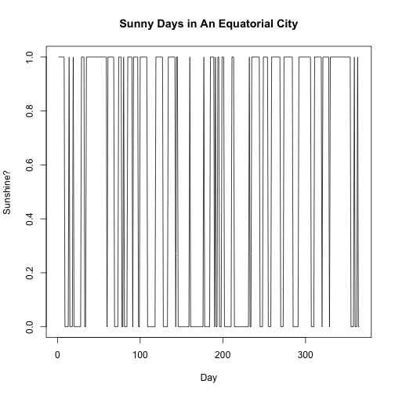

```r
plot(sunny.year, main="Sunny Days in An Equatorial City", xlab="Day", ylab="Sunshine?", ty="l")
```

### Different From Independence

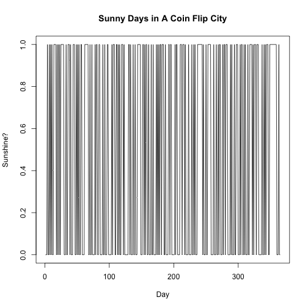

```r
boring.year <- rbinom(365, 1, 0.5)
plot(boring.year, main="Sunny Days in A Coin Flip City", xlab="Day", ylab="Sunshine?", ty="l")
```

### The above chain

Transitions are represented as a matrix: \( Q_{ij} \) is \( P(X_t = j|X_{t-1} = i) \).

```
     [,1] [,2]
[1,]  0.8  0.2
[2,]  0.2  0.8
```

### Flippy chain

```r
weird.year <- rep(NA, 365)
weird.year[1] <- 1
transition.matrix <- matrix (c(0.2, 0.8, 0.8, 0.2), nrow=2)
for (day in 2:365) weird.year[day] <- sample(1:2, 1, prob=transition.matrix[weird.year[day-1],])
```

### Flippy chain

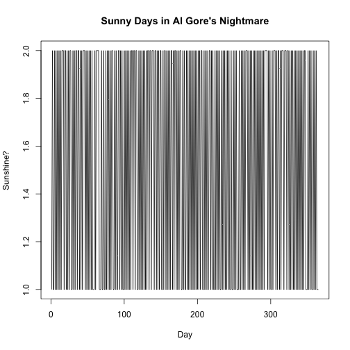

```r
plot(weird.year, main="Sunny Days in Al Gore's Nightmare", xlab="Day", ylab="Sunshine?", ty="l")
```

### General Markov Chain

```r
rmarkovchain <- function (nn,
                          transition.matrix,
                          start=sample(1:nrow(transition.matrix), 1)) {
  output <- rep (NA, nn)
  output[1] <- start
  for (day in 2:nn) output[day] <-
    sample(ncol(transition.matrix), 1,
           prob=transition.matrix[output[day-1],])
}
```

### Simple Unbounded Markov Chain

“Unbiased Random Walk”: Independent events atop a dependent structure.

```r
randomwalk <- function (nn, upprob=0.5, start=50) {
  output <- rep (NA, nn)
  output[1] <- start
  for (iteration in 2:nn)
    output[iteration] <-
      output[iteration-1] + 2*rbinom(1, 1, upprob) - 1
  output
}
```

### Simple Unbounded Markov Chain

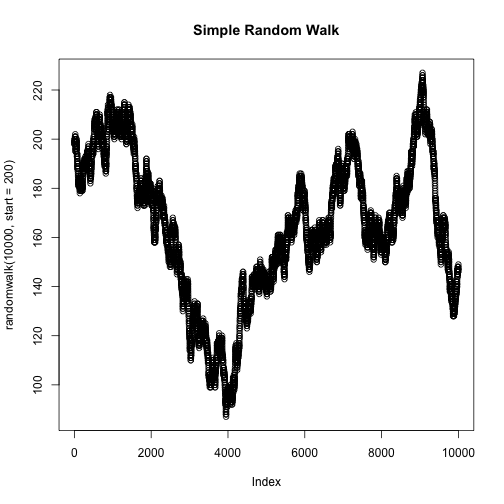

```r
plot (randomwalk(10000, start=200), main="Simple Random Walk")
```

### Simple Unbounded Markov Chain

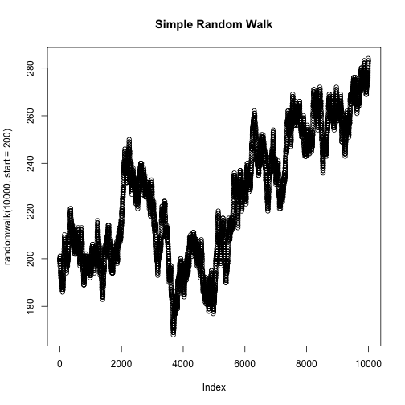

```r
plot (randomwalk(10000, start=200), main="Simple Random Walk")
```

### Simple Unbounded Markov Chain

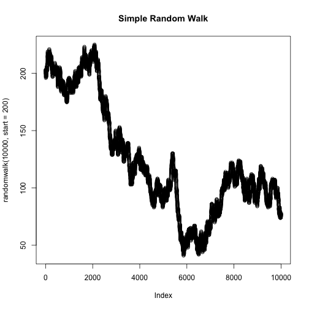

```r
plot (randomwalk(10000, start=200), main="Simple Random Walk")
```

### Simple Unbounded Markov Chain

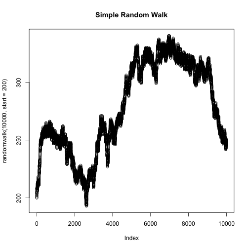

```r
plot (randomwalk(10000, start=200), main="Simple Random Walk")
```

### Linear Regression Example

Set up a small artificial dataset:

```r
set.seed(54321)
x = rep(seq(1, 4, length = 10), 3)
y = 5 + x + 4*x^2 + rnorm(30, 0, 3)
myData = data.frame(x,y)
```

### Linear Regression Example

Let's look at what we made:

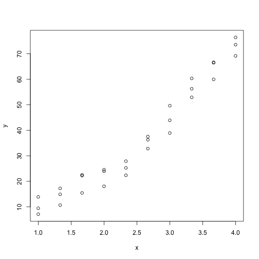

```r
plot(y ~ x)
```

### Linear Regression Example

The command for fitting a linear model in R is lm():

```r
my.lm = lm(y ~ x)
class(my.lm)
```

```
[1] "lm"
```

```r
names(my.lm)
```

```
 [1] "coefficients"  "residuals"     "effects"       "rank"
 [5] "fitted.values" "assign"        "qr"            "df.residual"
 [9] "xlevels"       "call"          "terms"         "model"
```

### Linear Regression Example

```r
summary(my.lm)
```

```
Call:
lm(formula = y ~ x)

Residuals:
     Min       1Q   Median       3Q      Max
-10.6116  -3.3102  -0.1931   4.6614   9.4080

Coefficients:
            Estimate Std. Error t value Pr(>|t|)
(Intercept)  -16.866      2.739  -6.156  1.2e-06 ***
x             21.362      1.023  20.875  < 2e-16 ***
---
Signif. codes:  0 '***' 0.001 '**' 0.01 '*' 0.05 '.' 0.1 ' ' 1

Residual standard error: 5.366 on 28 degrees of freedom
Multiple R-squared:  0.9396,    Adjusted R-squared:  0.9375
F-statistic: 435.8 on 1 and 28 DF,  p-value: < 2.2e-16
```

### Linear Regression Example

There are several inbuilt prediction functions in R, e.g.

```r
predict(my.lm)
```

```
        1         2         3         4         5         6         7
 4.496434 11.617116 18.737799 25.858481 32.979164 40.099846 47.220529
        8         9        10        11        12        13        14
54.341211 61.461894 68.582576  4.496434 11.617116 18.737799 25.858481
       15        16        17        18        19        20        21
32.979164 40.099846 47.220529 54.341211 61.461894 68.582576  4.496434
       22        23        24        25        26        27        28
11.617116 18.737799 25.858481 32.979164 40.099846 47.220529 54.341211
       29        30
61.461894 68.582576
```

### Linear Regression Example

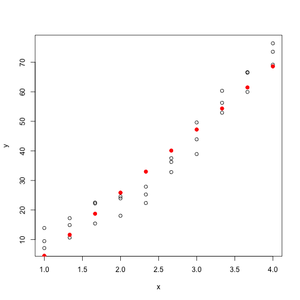

```r
plot(y ~ x)
points(my.lm$fitted.values ~ myData$x, pch = 19, col="red")
```

### Linear Regression Example

Let's look at some diagnostic plots:

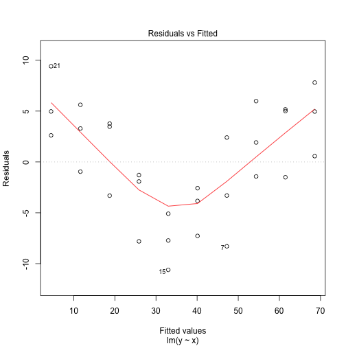

```r
plot(my.lm, which = 1)
```

### Linear Regression Example

And another one (you can go upto which=6)

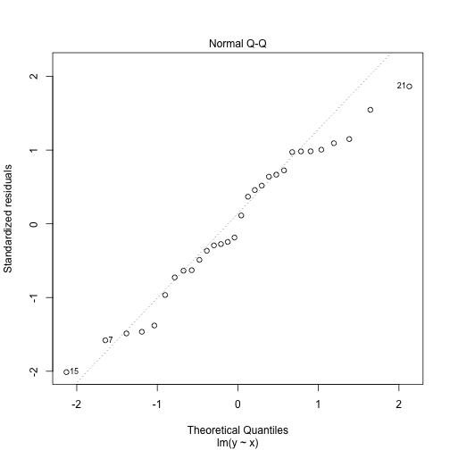

```r
plot(my.lm, which = 2)
```